# Mod 0: Hypothesis Testing

Jake Harvey

2025-02-04

# NYC Crimes 2024

## 1.

```r
df = read.csv("C:\\Users\\jphar\\OneDrive\\Documents\\APPLIED-STATISTICS\\NYPD_Arrest_Data__Year_to_Date_.csv")
kable(head(df))
```

| ARREST_KEY | ARREST_DATE | PD_CD | PD_DESC | KY_CD | OFNS_DESC | LAW_CODE | LAW_CAT_CD | ARREST_BORO | ARREST_PRECINCT | JURISDICTION_CODE | AGE_GROUP | PERP_SEX | PERP_RACE | X_COORD_CD | Y_COORD_CD | Latitude | Longitude | New.Georeferenced.Column |
| --- | --- | --- | --- | --- | --- | --- | --- | --- | --- | --- | --- | --- | --- | --- | --- | --- | --- | --- |
| 281369711 | 1/30/2024 | 177 | SEXUAL ABUSE | 116 | SEX CRIMES | PL 1306501 | F | M | 25 | 0 | 25-44 | M | BLACK | 1000558 | 231080 | 40.80093 | -73.94110 | POINT (-73.9410982410066 40.8009303727402) |
| 284561406 | 3/30/2024 | 105 | STRANGULATION 1ST | 106 | FELONY ASSAULT | PL 1211200 | F | B | 44 | 0 | 25-44 | M | BLACK | 1004297 | 242846 | 40.83321 | -73.92755 | POINT (-73.927554 40.833209) |
| 284896016 | 4/6/2024 | 105 | STRANGULATION 1ST | 106 | FELONY ASSAULT | PL 1211200 | F | M | 19 | 0 | 25-44 | M | BLACK | 997304 | 222853 | 40.77835 | -73.95286 | POINT (-73.952863 40.778348) |
| 285569016 | 4/18/2024 | 105 | STRANGULATION 1ST | 106 | FELONY ASSAULT | PL 1211200 | F | K | 69 | 0 | 25-44 | M | BLACK | 1010576 | 175628 | 40.64870 | -73.90513 | POINT (-73.905128 40.648698) |
| 287308954 | 5/22/2024 | 464 | JOSTLING | 230 | JOSTLING | PL 1652501 | M | M | 18 | 0 | 18-24 | M | WHITE | 991530 | 217373 | 40.76331 | -73.97372 | POINT (-73.973717 40.763313) |
| 286793332 | 5/13/2024 | 155 | RAPE 2 | 104 | RAPE | PL 1303001 | F | Q | 112 | 0 | 18-24 | M | BLACK HISPANIC | 1025401 | 202586 | 40.72264 | -73.85154 | POINT (-73.8515418216779 40.7226409964758) |

## 2.

I am using the age range for the qualitative portion. The only issue I have with the age is that it is stored in a range, <18, 18-24, 25-44, 45-64, and 65+. This means that the age range, although they are numbers, are stored as a data type. It also means that if I covert them to the midpoint of the range that the data will not have that many variables, and would more than likely cause the mean to be somewhere between 25-44. I am going to do three different things for each problem. The first is just run it as it is with the data I am given. The second is to take the midpoint of the ranges. The third is to use a random number generator to pick a number between these age ranges and use it.

Age Range Counter

```r
Age_Range <- df |>
  filter(!is.na(AGE_GROUP)) |>
  group_by(AGE_GROUP) |>
  summarise(Age_Range = n())
kable(print(Age_Range))
```

```
## # A tibble: 5 × 2
##   AGE_GROUP Age_Range
##   <chr>         <int>
## 1 18-24         43174
## 2 25-44        152034
## 3 45-64         51121
## 4 65+            4649
## 5 <18            9525
```

| AGE_GROUP | Age_Range |
| --- | --- |
| 18-24 | 43174 |
| 25-44 | 152034 |
| 45-64 | 51121 |
| 65+ | 4649 |
| <18 | 9525 |

Random Number Generator

```r
numCores <- detectCores() - 1
cl <- makeCluster(numCores)
registerDoParallel(cl)

Generate_Random_Age <- function(Age_Range) {
  case_when(
    Age_Range == '<18' ~ sample(15:17, 1),
    Age_Range == '18-24' ~ sample(18:24, 1),
    Age_Range == '25-44' ~ sample(25:44, 1),
    Age_Range == '45-64' ~ sample(45:64, 1),
    Age_Range == '65+' ~ sample(65:75, 1)
  )
}

Random_Ages <- foreach(age_group = df$AGE_GROUP, .combine = c, .packages = 'dplyr') %dopar% {
  Generate_Random_Age(age_group)
}

df <- df |> mutate(Random_Ages = Random_Ages)

kable(print(head(df, 10)))
```

```
##    ARREST_KEY ARREST_DATE PD_CD           PD_DESC KY_CD        OFNS_DESC
## 1   281369711   1/30/2024   177      SEXUAL ABUSE   116       SEX CRIMES
## 2   284561406   3/30/2024   105 STRANGULATION 1ST   106   FELONY ASSAULT
## 3   284896016    4/6/2024   105 STRANGULATION 1ST   106   FELONY ASSAULT
## 4   285569016   4/18/2024   105 STRANGULATION 1ST   106   FELONY ASSAULT
## 5   287308954   5/22/2024   464          JOSTLING   230         JOSTLING
## 6   286793332   5/13/2024   155            RAPE 2   104             RAPE
## 7   279892607    1/3/2024   153            RAPE 3   104             RAPE
## 8   280263905   1/10/2024   157            RAPE 1   104             RAPE
## 9   288072319    6/6/2024   808           TAX LAW   125 OTHER STATE LAWS
## 10  288408753   6/12/2024   105 STRANGULATION 1ST   106   FELONY ASSAULT
##      LAW_CODE LAW_CAT_CD ARREST_BORO ARREST_PRECINCT JURISDICTION_CODE
## 1  PL 1306501          F           M              25                 0
## 2  PL 1211200          F           B              44                 0
## 3  PL 1211200          F           M              19                 0
```

[output cut: 29 more lines]

| ARREST_KEY | ARREST_DATE | PD_CD | PD_DESC | KY_CD | OFNS_DESC | LAW_CODE | LAW_CAT_CD | ARREST_BORO | ARREST_PRECINCT | JURISDICTION_CODE | AGE_GROUP | PERP_SEX | PERP_RACE | X_COORD_CD | Y_COORD_CD | Latitude | Longitude | New.Georeferenced.Column | Random_Ages |
| --- | --- | --- | --- | --- | --- | --- | --- | --- | --- | --- | --- | --- | --- | --- | --- | --- | --- | --- | --- |
| 281369711 | 1/30/2024 | 177 | SEXUAL ABUSE | 116 | SEX CRIMES | PL 1306501 | F | M | 25 | 0 | 25-44 | M | BLACK | 1000558 | 231080 | 40.80093 | -73.94110 | POINT (-73.9410982410066 40.8009303727402) | 44 |
| 284561406 | 3/30/2024 | 105 | STRANGULATION 1ST | 106 | FELONY ASSAULT | PL 1211200 | F | B | 44 | 0 | 25-44 | M | BLACK | 1004297 | 242846 | 40.83321 | -73.92755 | POINT (-73.927554 40.833209) | 26 |
| 284896016 | 4/6/2024 | 105 | STRANGULATION 1ST | 106 | FELONY ASSAULT | PL 1211200 | F | M | 19 | 0 | 25-44 | M | BLACK | 997304 | 222853 | 40.77835 | -73.95286 | POINT (-73.952863 40.778348) | 44 |
| 285569016 | 4/18/2024 | 105 | STRANGULATION 1ST | 106 | FELONY ASSAULT | PL 1211200 | F | K | 69 | 0 | 25-44 | M | BLACK | 1010576 | 175628 | 40.64870 | -73.90513 | POINT (-73.905128 40.648698) | 31 |
| 287308954 | 5/22/2024 | 464 | JOSTLING | 230 | JOSTLING | PL 1652501 | M | M | 18 | 0 | 18-24 | M | WHITE | 991530 | 217373 | 40.76331 | -73.97372 | POINT (-73.973717 40.763313) | 20 |
| 286793332 | 5/13/2024 | 155 | RAPE 2 | 104 | RAPE | PL 1303001 | F | Q | 112 | 0 | 18-24 | M | BLACK HISPANIC | 1025401 | 202586 | 40.72264 | -73.85154 | POINT (-73.8515418216779 40.7226409964758) | 23 |
| 279892607 | 1/3/2024 | 153 | RAPE 3 | 104 | RAPE | PL 1302503 | F | Q | 113 | 0 | 25-44 | M | BLACK | 1046315 | 187088 | 40.67998 | -73.77623 | POINT (-73.7762339071953 40.6799807384666) | 38 |
| 280263905 | 1/10/2024 | 157 | RAPE 1 | 104 | RAPE | PL 1303501 | F | B | 42 | 0 | 25-44 | M | BLACK | 1008690 | 238862 | 40.82227 | -73.91170 | POINT (-73.911697780277 40.8222710411331) | 40 |
| 288072319 | 6/6/2024 | 808 | TAX LAW | 125 | OTHER STATE LAWS | TAX18140B3 | F | M | 13 | 0 | 45-64 | M | BLACK | 987373 | 210805 | 40.74529 | -73.98873 | POINT (-73.98872939424497 40.7452870263689) | 54 |
| 288408753 | 6/12/2024 | 105 | STRANGULATION 1ST | 106 | FELONY ASSAULT | PL 1211200 | F | B | 52 | 0 | 45-64 | M | BLACK | 1012026 | 253649 | 40.86284 | -73.89958 | POINT (-73.89958 40.86284) | 57 |

```r
stopCluster(cl)
```

# Mean

As is

```r
Age_Range_List <- c(43174, 152034, 51121, 4649, 9525)

result.mean <- mean(Age_Range_List)
kable(print(result.mean))
```

```
## [1] 52100.6
```

| x |
| --- |
| 52100.6 |

Based off of the mean, this data tells me nothing.

Midpoint

```r
age_ranges <- data.frame(
  AGE_GROUP = c('<18', '18-24', '25-44', '45-64', '65+'),
  Midpoint = c(16, 21, 35, 55, 70)
)

Age_Range <- df |>
  filter(!is.na(AGE_GROUP)) |>
  group_by(AGE_GROUP) |>
  summarise(Age_Range = n())

Age_Range <- Age_Range |>
  left_join(age_ranges, by = "AGE_GROUP")

weighted_midpoints <- sum(Age_Range$Age_Range * Age_Range$Midpoint)

total_count <- sum(Age_Range$Age_Range)

result.mean <- weighted_midpoints / total_count
kable(print(result.mean))
```

```
## [1] 36.53443
```

| x |
| --- |
| 36.53443 |

Taking the midpoint gives me a better mean.

Random Ages

```r
result.mean <- mean(df$Random_Ages, na.rm = FALSE)
kable(print(result.mean))
```

```
## [1] 36.12544
```

| x |
| --- |
| 36.12544 |

The random ages helps solidify the midpoints mean.

# Standard Deviation

As is

```r
SD<-sqrt(sum((Age_Range_List-mean(Age_Range_List))^2/(length(Age_Range_List)-1)))

kable(print(SD))
```

```
## [1] 59438.34
```

| x |
| --- |
| 59438.34 |

Again, using the ranges does not get me anything.

Midpoint

```r
SD <- sd(Age_Range$Midpoint, na.rm = FALSE)

kable(print(SD))
```

```
## [1] 22.832
```

| x |
| --- |
| 22.832 |

This is a much better standard deviation compared to before, but again using the midpoint does not allow for very much variation.

Random Ages

```r
SD<-sd(df$Random_Ages, na.rm = FALSE)

kable(print(SD))
```

```
## [1] 12.95318
```

| x |
| --- |
| 12.95318 |

Using the random ages gives me the best standard deviation thus far.

# 5-Number Summary

As is

```r
FNS <- fivenum(Age_Range$Age_Range)

kable(print(FNS))
```

```
## [1]   4649   9525  43174  51121 152034
```

| x |
| --- |
| 4649 |
| 9525 |
| 43174 |
| 51121 |
| 152034 |

I am just given all 5 quantities of the ranges.

Midpoint

```r
FNS <- fivenum(Age_Range$Midpoint)

kable(print(FNS))
```

```
## [1] 16 21 35 55 70
```

| x |
| --- |
| 16 |
| 21 |
| 35 |
| 55 |
| 70 |

Again, I am just given all 5 midpoints.

Random Ages

```r
FNS <- fivenum(df$Random_Ages)

kable(print(FNS))
```

```
## [1] 15 26 35 43 75
```

| x |
| --- |
| 15 |
| 26 |
| 35 |
| 43 |
| 75 |

# Histogram

As is

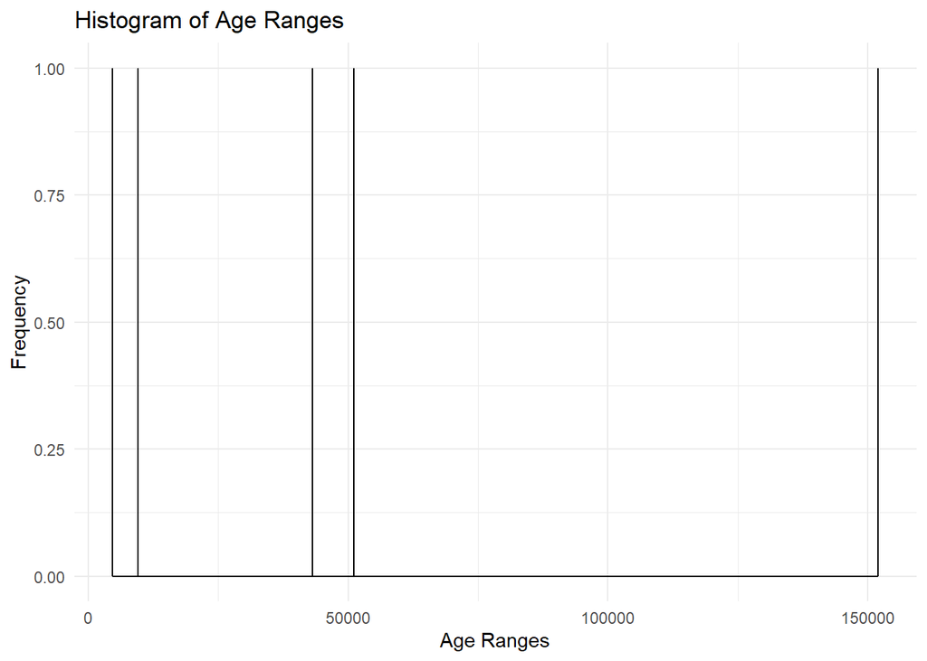

```r
h <- ggplot(Age_Range, aes(x = Age_Range)) +
  geom_histogram(binwidth = 5, fill = "#ff5200", color = "black") +
  labs(title = "Histogram of Age Ranges", x = "Age Ranges", y = "Frequency") +
  theme_minimal()

print(h)
```

This histogram is not good at all, and I should of used a different piece of data.

Midpoint

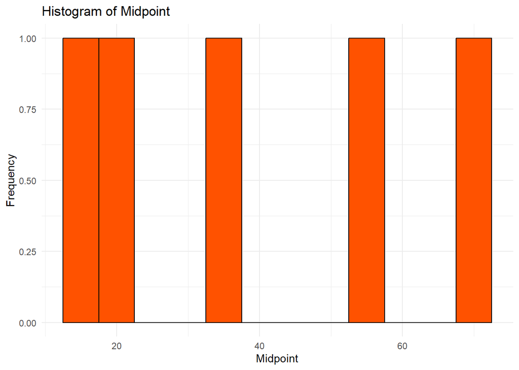

```r
h <- ggplot(Age_Range, aes(x = Midpoint)) +
  geom_histogram(binwidth = 5, fill = "#ff5200", color = "black") +
  labs(title = "Histogram of Midpoint", x = "Midpoint", y = "Frequency") +
  theme_minimal()

print(h)
```

This one is better, but it still has its own issues.

Random Ages

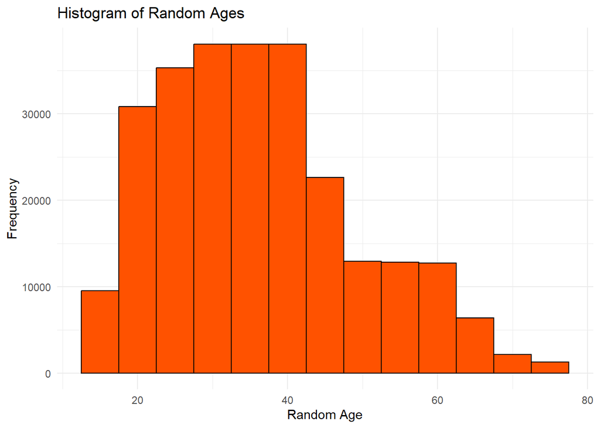

```r
h <- ggplot(df, aes(x = Random_Ages)) +
  geom_histogram(binwidth = 5, fill = "#ff5200", color = "black") +
  labs(title = "Histogram of Random Ages", x = "Random Age", y = "Frequency") +
  theme_minimal()

print(h)
```

This histogram shows the rise to the most average age for committing crimes, and also shows its decline over time.

# Box Plot

As is

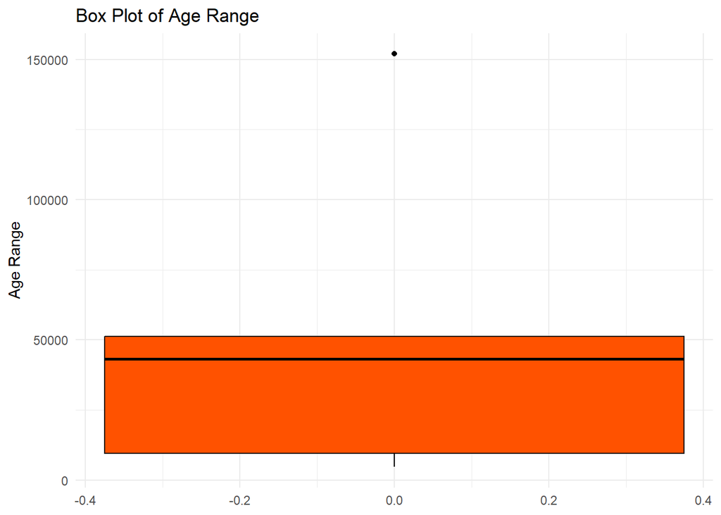

```r
b <- ggplot(Age_Range, aes(y = Age_Range)) +
  geom_boxplot(fill = "#ff5200", color = "black") +
  labs(title = "Box Plot of Age Range", y = "Age Range") +
  theme_minimal()

print(b)
```

This boxplot just shows the ranges.

Midpoint

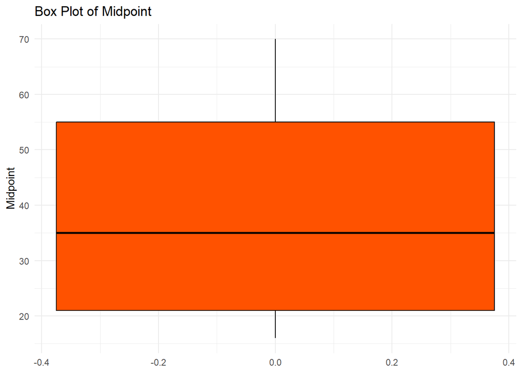

```r
b <- ggplot(Age_Range, aes(y = Midpoint)) +
  geom_boxplot(fill = "#ff5200", color = "black") +
  labs(title = "Box Plot of Midpoint", y = "Midpoint") +
  theme_minimal()

print(b)
```

There is more variance in this one.

Random Ages

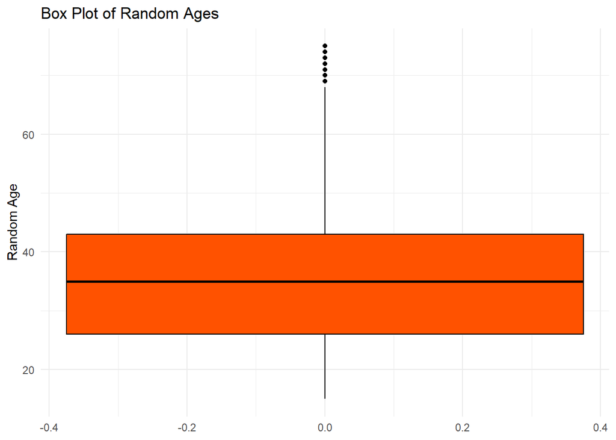

```r
b <- ggplot(df, aes(y = Random_Ages)) +
  geom_boxplot(fill = "#ff5200", color = "black") +
  labs(title = "Box Plot of Random Ages", y = "Random Age") +
  theme_minimal()

print(b)
```

This one shows the outliers and mean much better than the previous two did.

# QQ Plot

As is

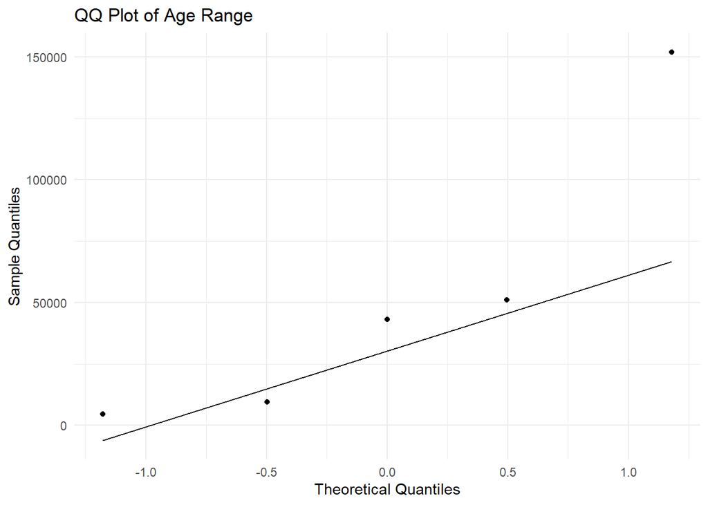

```r
qq <- ggplot(Age_Range, aes(sample = Age_Range)) +
  stat_qq() +
  stat_qq_line() +
  labs(title = "QQ Plot of Age Range", x = "Theoretical Quantiles", y = "Sample Quantiles") +
  theme_minimal()

print(qq)
```

The qq line fits as best as it can, but there is one major outlier.

Midpoint

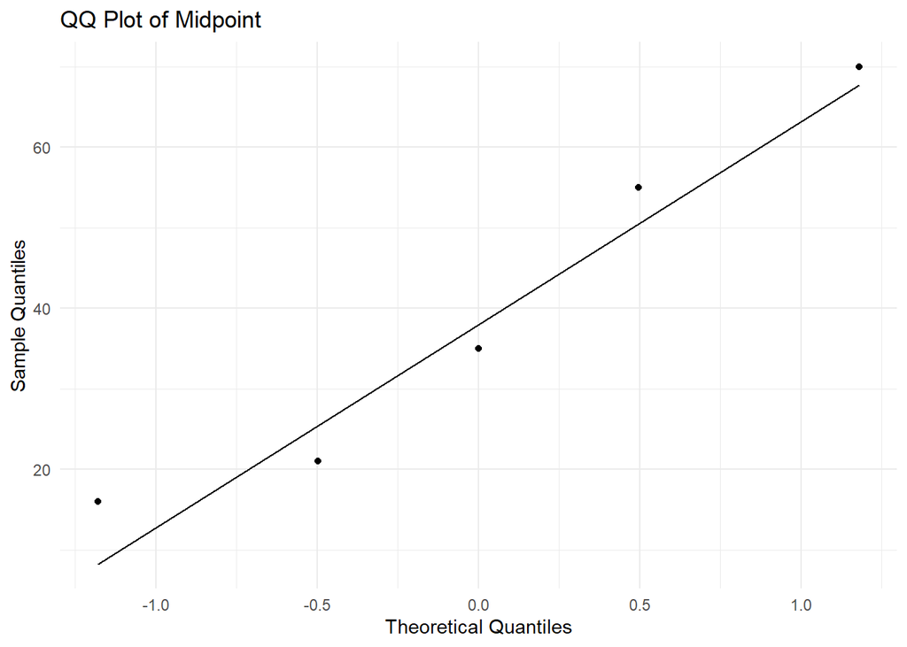

```r
qq <- ggplot(Age_Range, aes(sample = Midpoint)) +
  stat_qq() +
  stat_qq_line() +
  labs(title = "QQ Plot of Midpoint", x = "Theoretical Quantiles", y = "Sample Quantiles") +
  theme_minimal()

print(qq)
```

This qq plot shows a much closer connection between the points.

Random Ages

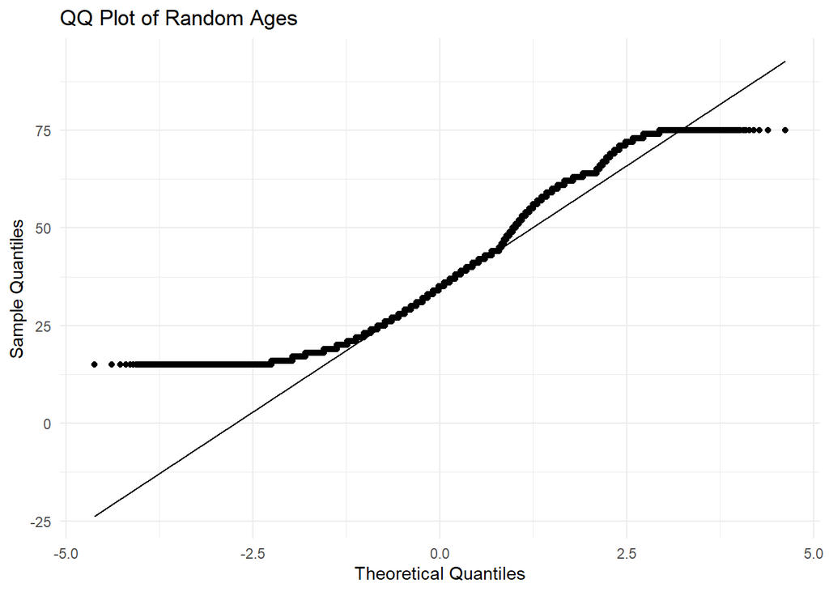

```r
qq <- ggplot(df, aes(sample = Random_Ages)) +
  stat_qq() +
  stat_qq_line() +
  labs(title = "QQ Plot of Random Ages", x = "Theoretical Quantiles", y = "Sample Quantiles") +
  theme_minimal()

print(qq)
```

# Frequency

| PD_DESC | Frequency |
| --- | --- |
| (null) | 32 |
| A.B.C.,FALSE PROOF OF AGE | 2 |
| ABANDON ANIMAL | 4 |
| ACCOSTING,FRAUDULENT | 44 |
| ADM.CODE,UNCLASSIFIED MISDEMEA | 13 |
| ADM.CODE,UNCLASSIFIED VIOLATIO | 26 |
| AGGRAVATED CRIMINAL CONTEMPT | 258 |
| AGGRAVATED GRAND LARCENY OF ATM | 174 |
| AGGRAVATED HARASSMENT 1 | 75 |
| AGGRAVATED HARASSMENT 2 | 3558 |

These are the descriptions of the crimes based on the police departments, and how frequent they occurred.

# Relative Frequency

```r
relative_frequency_table <- df |>
  group_by(PD_DESC) |>
  summarise(Frequency = n() / nrow(df)) |>
  arrange(desc(Frequency))

kable(head(relative_frequency_table, 10))
```

| PD_DESC | Frequency |
| --- | --- |
| ASSAULT 3 | 0.1082598 |
| LARCENY,PETIT FROM OPEN AREAS, | 0.1040564 |
| ASSAULT 2,1,UNCLASSIFIED | 0.0599302 |
| TRAFFIC,UNCLASSIFIED MISDEMEAN | 0.0508785 |
| THEFT OF SERVICES, UNCLASSIFIE | 0.0470820 |
| ROBBERY,OPEN AREA UNCLASSIFIED | 0.0459342 |
| PUBLIC ADMINISTRATION,UNCLASSI | 0.0383220 |
| LARCENY,GRAND FROM OPEN AREAS, UNATTENDED | 0.0373854 |
| CONTROLLED SUBSTANCE, POSSESSI | 0.0348825 |
| MENACING,UNCLASSIFIED | 0.0249479 |

The relative frequency tells me that out of all of the crime the most common is Assault 3.

# C.

```r
two_way_table <- table(df$ARREST_BORO, df$OFNS_DESC)

two_way_df <- as.data.frame.matrix(two_way_table)

kable(print(two_way_df))
```

```
##   (null) ADMINISTRATIVE CODE ADMINISTRATIVE CODES
## B      4                  11                    0
## K     10                  82                    1
## M      9                  33                    1
## Q      9                  33                    0
## S      0                   0                    0
##   ALCOHOLIC BEVERAGE CONTROL LAW ANTICIPATORY OFFENSES ARSON
## B                             26                    27    44
## K                             41                     4    30
## M                             29                    37    25
## Q                             94                     0    20
## S                              3                     1     2
##   ASSAULT 3 & RELATED OFFENSES BURGLAR'S TOOLS BURGLARY
## B                         9706              75     1349
## K                        10401             260     1776
## M                         7330             195     1947
## Q                         9259             191     1215
## S                         1542              18      163
##   CANNABIS RELATED OFFENSES CHILD ABANDONMENT/NON SUPPORT 1
## B                        94                              34
## K                        51                              16
## M                        57                              12
## Q                       190                              18
## S                         5                               4
##   CRIMINAL MISCHIEF & RELATED OF CRIMINAL TRESPASS DANGEROUS DRUGS
## B                           2668               497            3923
## K                           3567               945            5463
## M                           2669               760            4959
## Q                           2383               469            3175
## S                            567                98             999
##   DANGEROUS WEAPONS DISORDERLY CONDUCT DISRUPTION OF A RELIGIOUS SERV ESCAPE 3
## B              2490                 18                              0        5
## K              3914                 25                              0        3
## M              1948                319                              3        2
## Q              2042                 12                              0        2
## S               386                  1                              3        0
##   FELONY ASSAULT FOR OTHER AUTHORITIES FORGERY FORTUNE TELLING FRAUDS
## B           6007                   304     467               0    231
## K           6075                   236    1346               0    237
## M           4233                   662    1842               1    300
```

[output cut: 65 more lines]

```
## M          9800                           958                              28
## Q          5709                           865                             286
## S          1153                           124                              13
##   RAPE ROBBERY SEX CRIMES THEFT-FRAUD UNAUTHORIZED USE OF A VEHICLE
## B  220    3108       1176          35                           101
## K  206    3164       1327          60                           196
## M  125    2837       1101          56                            66
## Q  215    2647       2102          49                           155
## S   26     264        234           9                            39
##   VEHICLE AND TRAFFIC LAWS
## B                     3657
## K                     4425
## M                     1717
## Q                     2847
## S                     1137
```

|  | (null) | ADMINISTRATIVE CODE | ADMINISTRATIVE CODES | ALCOHOLIC BEVERAGE CONTROL LAW | ANTICIPATORY OFFENSES | ARSON | ASSAULT 3 & RELATED OFFENSES | BURGLAR’S TOOLS | BURGLARY | CANNABIS RELATED OFFENSES | CHILD ABANDONMENT/NON SUPPORT 1 | CRIMINAL MISCHIEF & RELATED OF | CRIMINAL TRESPASS | DANGEROUS DRUGS | DANGEROUS WEAPONS | DISORDERLY CONDUCT | DISRUPTION OF A RELIGIOUS SERV | ESCAPE 3 | FELONY ASSAULT | FOR OTHER AUTHORITIES | FORGERY | FORTUNE TELLING | FRAUDS | FRAUDULENT ACCOSTING | GAMBLING | GRAND LARCENY | GRAND LARCENY OF MOTOR VEHICLE | HARRASSMENT 2 | HOMICIDE-NEGLIGENT-VEHICLE | … |
| --- | --- | --- | --- | --- | --- | --- | --- | --- | --- | --- | --- | --- | --- | --- | --- | --- | --- | --- | --- | --- | --- | --- | --- | --- | --- | --- | --- | --- | --- | --- |
| B | 4 | 11 | 0 | 26 | 27 | 44 | 9706 | 75 | 1349 | 94 | 34 | 2668 | 497 | 3923 | 2490 | 18 | 0 | 5 | 6007 | 304 | 467 | 0 | 231 | 3 | 52 | 1998 | 538 | 21 | 1 | … |
| K | 10 | 82 | 1 | 41 | 4 | 30 | 10401 | 260 | 1776 | 51 | 16 | 3567 | 945 | 5463 | 3914 | 25 | 0 | 3 | 6075 | 236 | 1346 | 0 | 237 | 0 | 185 | 2567 | 631 | 20 | 3 | … |
| M | 9 | 33 | 1 | 29 | 37 | 25 | 7330 | 195 | 1947 | 57 | 12 | 2669 | 760 | 4959 | 1948 | 319 | 3 | 2 | 4233 | 662 | 1842 | 1 | 300 | 38 | 44 | 4475 | 201 | 33 | 1 | … |
| Q | 9 | 33 | 0 | 94 | 0 | 20 | 9259 | 191 | 1215 | 190 | 18 | 2383 | 469 | 3175 | 2042 | 12 | 0 | 2 | 5437 | 163 | 1203 | 0 | 215 | 3 | 71 | 2338 | 623 | 20 | 3 | … |
| S | 0 | 0 | 0 | 3 | 1 | 2 | 1542 | 18 | 163 | 5 | 4 | 567 | 98 | 999 | 386 | 1 | 3 | 0 | 854 | 25 | 103 | 0 | 37 | 0 | 0 | 426 | 93 | 2 | 0 | … |

```r
proportions <- prop.table(two_way_table, 1)

proportions_df <- as.data.frame.matrix(proportions)

kable(print(proportions_df))
```

```
##         (null) ADMINISTRATIVE CODE ADMINISTRATIVE CODES
## B 6.835153e-05        0.0001879667         0.000000e+00
## K 1.382648e-04        0.0011337712         1.382648e-05
## M 1.452339e-04        0.0005325243         1.613710e-05
## Q 1.589179e-04        0.0005826991         0.000000e+00
## S 0.000000e+00        0.0000000000         0.000000e+00
##   ALCOHOLIC BEVERAGE CONTROL LAW ANTICIPATORY OFFENSES        ARSON
## B                   0.0004442850          4.613728e-04 0.0007518669
## K                   0.0005668856          5.530591e-05 0.0004147943
## M                   0.0004679759          5.970727e-04 0.0004034275
## Q                   0.0016598097          0.000000e+00 0.0003531510
## S                   0.0002713704          9.045681e-05 0.0001809136
##   ASSAULT 3 & RELATED OFFENSES BURGLAR'S TOOLS   BURGLARY
## B                    0.1658550     0.001281591 0.02305155
## K                    0.1438092     0.003594884 0.02455582
## M                    0.1182849     0.003146735 0.03141894
## Q                    0.1634913     0.003372592 0.02145392
## S                    0.1394844     0.001628223 0.01474446
##   CANNABIS RELATED OFFENSES CHILD ABANDONMENT/NON SUPPORT 1
## B              0.0016062610                    0.0005809880
## K              0.0007051504                    0.0002212236
## M              0.0009198147                    0.0001936452
## Q              0.0033549344                    0.0003178359
## S              0.0004522840                    0.0003618272
##   CRIMINAL MISCHIEF & RELATED OF CRIMINAL TRESPASS DANGEROUS DRUGS
## B                     0.04559047       0.008492678      0.06703576
## K                     0.04931905       0.013066021      0.07553405
## M                     0.04306992       0.012264197      0.08002388
## Q                     0.04207794       0.008281391      0.05606272
## S                     0.05128901       0.008864767      0.09036635
##   DANGEROUS WEAPONS DISORDERLY CONDUCT DISRUPTION OF A RELIGIOUS SERV
## B        0.04254883       3.075819e-04                   0.0000000000
## K        0.05411683       3.456619e-04                   0.0000000000
## M        0.03143507       5.147735e-03                   0.0000484113
## Q        0.03605672       2.118906e-04                   0.0000000000
## S        0.03491633       9.045681e-05                   0.0002713704
##       ESCAPE 3 FELONY ASSAULT FOR OTHER AUTHORITIES     FORGERY FORTUNE TELLING
## B 8.543941e-05     0.10264691           0.005194716 0.007980041     0.00000e+00
## K 4.147943e-05     0.08399585           0.003263049 0.018610439     0.00000e+00
## M 3.227420e-05     0.06830835           0.010682761 0.029724540     1.61371e-05
```

[output cut: 71 more lines]

```
## M    0.15814359                    0.01545934                    0.0004518388
## Q    0.10080695                    0.01527378                    0.0050500592
## S    0.10429670                    0.01121664                    0.0011759385
##          RAPE    ROBBERY SEX CRIMES  THEFT-FRAUD UNAUTHORIZED USE OF A VEHICLE
## B 0.003759334 0.05310914 0.02009535 0.0005980759                   0.001725876
## K 0.002848254 0.04374698 0.01834774 0.0008295887                   0.002709990
## M 0.002017138 0.04578095 0.01776695 0.0009036776                   0.001065049
## Q 0.003796373 0.04673953 0.03711617 0.0008652199                   0.002736920
## S 0.002351877 0.02388060 0.02116689 0.0008141113                   0.003527815
##   VEHICLE AND TRAFFIC LAWS
## B               0.06249039
## K               0.06118216
## M               0.02770740
## Q               0.05027104
## S               0.10284939
```

|  | (null) | ADMINISTRATIVE CODE | ADMINISTRATIVE CODES | ALCOHOLIC BEVERAGE CONTROL LAW | ANTICIPATORY OFFENSES | ARSON | ASSAULT 3 & RELATED OFFENSES | BURGLAR’S TOOLS | BURGLARY | CANNABIS RELATED OFFENSES | CHILD ABANDONMENT/NON SUPPORT 1 | CRIMINAL MISCHIEF & RELATED OF | CRIMINAL TRESPASS | DANGEROUS DRUGS | DANGEROUS WEAPONS | DISORDERLY CONDUCT | DISRUPTION OF A RELIGIOUS SERV | ESCAPE 3 | FELONY ASSAULT | FOR OTHER AUTHORITIES | FORGERY | FORTUNE TELLING | FRAUDS | FRAUDULENT ACCOSTING | GAMBLING | GRAND LARCENY | GRAND LARCENY OF MOTOR VEHICLE | HARRASSMENT 2 | HOMICIDE-NEGLIGENT-VEHICLE | … |
| --- | --- | --- | --- | --- | --- | --- | --- | --- | --- | --- | --- | --- | --- | --- | --- | --- | --- | --- | --- | --- | --- | --- | --- | --- | --- | --- | --- | --- | --- | --- |
| B | 0.0000684 | 0.0001880 | 0.00e+00 | 0.0004443 | 0.0004614 | 0.0007519 | 0.1658550 | 0.0012816 | 0.0230516 | 0.0016063 | 0.0005810 | 0.0455905 | 0.0084927 | 0.0670358 | 0.0425488 | 0.0003076 | 0.0000000 | 8.54e-05 | 0.1026469 | 0.0051947 | 0.0079800 | 0.00e+00 | 0.0039473 | 0.0000513 | 0.0008886 | 0.0341416 | 0.0091933 | 0.0003588 | 1.71e-05 | … |
| K | 0.0001383 | 0.0011338 | 1.38e-05 | 0.0005669 | 0.0000553 | 0.0004148 | 0.1438092 | 0.0035949 | 0.0245558 | 0.0007052 | 0.0002212 | 0.0493190 | 0.0130660 | 0.0755340 | 0.0541168 | 0.0003457 | 0.0000000 | 4.15e-05 | 0.0839959 | 0.0032630 | 0.0186104 | 0.00e+00 | 0.0032769 | 0.0000000 | 0.0025579 | 0.0354926 | 0.0087245 | 0.0002765 | 4.15e-05 | … |
| M | 0.0001452 | 0.0005325 | 1.61e-05 | 0.0004680 | 0.0005971 | 0.0004034 | 0.1182849 | 0.0031467 | 0.0314189 | 0.0009198 | 0.0001936 | 0.0430699 | 0.0122642 | 0.0800239 | 0.0314351 | 0.0051477 | 0.0000484 | 3.23e-05 | 0.0683083 | 0.0106828 | 0.0297245 | 1.61e-05 | 0.0048411 | 0.0006132 | 0.0007100 | 0.0722135 | 0.0032436 | 0.0005325 | 1.61e-05 | … |
| Q | 0.0001589 | 0.0005827 | 0.00e+00 | 0.0016598 | 0.0000000 | 0.0003532 | 0.1634913 | 0.0033726 | 0.0214539 | 0.0033549 | 0.0003178 | 0.0420779 | 0.0082814 | 0.0560627 | 0.0360567 | 0.0002119 | 0.0000000 | 3.53e-05 | 0.0960041 | 0.0028782 | 0.0212420 | 0.00e+00 | 0.0037964 | 0.0000530 | 0.0012537 | 0.0412834 | 0.0110007 | 0.0003532 | 5.30e-05 | … |
| S | 0.0000000 | 0.0000000 | 0.00e+00 | 0.0002714 | 0.0000905 | 0.0001809 | 0.1394844 | 0.0016282 | 0.0147445 | 0.0004523 | 0.0003618 | 0.0512890 | 0.0088648 | 0.0903664 | 0.0349163 | 0.0000905 | 0.0002714 | 0.00e+00 | 0.0772501 | 0.0022614 | 0.0093171 | 0.00e+00 | 0.0033469 | 0.0000000 | 0.0000000 | 0.0385346 | 0.0084125 | 0.0001809 | 0.00e+00 | … |

Assuming that the names of the boroughs are B for Bronx, K for Brooklyn, M for Manhattan, Q for Queens, and S for Staten Island, and going off of the categories of the crimes that were committed there is some relations to be made between them and the types of crimes. For the majority of the crimes there is a pretty even range across all 5 boroughs based on the area that they cover and the category that crime falls into. However, when it comes to the amount of crimes committed it is almost always true that there are less crimes committed in Staten Islands boroughs then in any other borough.

# 3

# A.

H0: Using the mean of the Random_Ages data is equal to 36.

H1: Using the mean of the Random_Ages data is not equal to 36.

```r
fixed_value <- 36

t_test_result <- t.test(df$Random_Ages, mu = fixed_value, alternative = "two.sided")

print(t_test_result)
```

```
##
##  One Sample t-test
##
## data:  df$Random_Ages
## t = 4.9428, df = 260502, p-value = 7.706e-07
## alternative hypothesis: true mean is not equal to 36
## 95 percent confidence interval:
##  36.07570 36.17518
## sample estimates:
## mean of x
##  36.12544
```

# B.

H0: The means of the Bronx and Staten Island when using Random_Ages is equal.

H1: The means of the Bronx and Staten Island when using Random_Ages is not equal.

```r
group1 <- df |> filter(ARREST_BORO == 'B') |> select(Random_Ages)
group2 <- df |> filter(ARREST_BORO == 'S') |> select(Random_Ages)

t_test_result <- t.test(group1$Random_Ages, group2$Random_Ages, alternative = "two.sided")

print(t_test_result)
```

```
##
##  Welch Two Sample t-test
##
## data:  group1$Random_Ages and group2$Random_Ages
## t = -7.8363, df = 15221, p-value = 4.946e-15
## alternative hypothesis: true difference in means is not equal to 0
## 95 percent confidence interval:
##  -1.3299419 -0.7977373
## sample estimates:
## mean of x mean of y
##  35.43892  36.50276
```

# 4.

My data set is all of the arrests made in 2024 in New York City. The information that is provided by the data set contains everything regarding the arrests up to who the person was. Crimes, categories of crime, dates, and arresting boroughs are just some parts of this data set. The age range of the suspect is a big part of this data set as well as the arresting boroughs. I found the data set on data.gov.

Link: https://catalog.data.gov/dataset/nypd-arrest-data-year-to-date

The conclusion that I have made based on the results of the test is that the average age of the suspect who was arrested is just over 36. The ages I was given are in ranges, so it is only a guess based off of the random age generator. If there were a couple of more details provided by the data set I could probably prove or disprove this assumption. There is a lot that can be done with this data set, predictive readings on crimes in certain locations during certain times of the year just being one example. I would love to work with this data set going on to the future!